# 20. 回帰分析がよくわかるシミュレーション

Masahiko Asano

2022-09-10

- **このセクションで使っている `R packages`**

```r
library(tidyverse)
library(stargazer)
library(DT)
```

# 1. モンテ・カルロシミュレーション

- 回帰分析のしくみ（特に信頼区間の意味）を理解するために、簡単なモンテ・ カルロシミュレーションを行う
- シミュレーションでは、自分で母数を設定し、データを人工的に作り出す
- 特徴を知りたい分析手法（ここでは `OLS` ）を人工的に作り出したデータに当てはめ、母数を期待通りに推測できるかどうか確認する
- ここでは、単回帰を例にシミュレーションを行う このシミュレーションを行う主な目的は以下の 3 つ
1. 最小二乗法が想定するデータ生成過程 (`data generating process`) を理解する
2. 最小二乗推定量（`OLSE: Ordinary Least Squares Estimator`）の基本的な性質を理解する
3. 信頼区間 (`Confidence Interval`) の意味を理解する
- 単回帰モデルは次の式で表せる

$$y_i \sim \mathrm{N}(\alpha_1 + \alpha_2
x_i, \sigma^2)- - - i = 1, 2, \dots, n$$

- 設定する母数は次の 3 つである

```r
alpha1 <- 10 # 切片の値は 10
alpha2 <- 3  # 傾き（独立変数の係数）は 3
sigma  <- 6  # 標準偏差は 6
```

- 単回帰モデルが想定する**データ生成過程***に従って、データを生成する
- サンプルサイズ = 100 と指定

```r
n <- 100
```

- 同一のサンプル結果を得られるよう特定のノイズを設定

```r
set.seed(20210328)
```

- 最大値 10 の一様分布から長さ `n` の `x` ベクトルを無作為抽出

```r
x <- runif(n, 0, 10)
```

- `y` の値を指定

```r
y <- rnorm(n, alpha1 + alpha2 * x, sd = sigma)
```

- 設定に従って正規分布から抽出した `x` と `y` をデータフレームに入れる

```r
df <- data.frame(y = y, x = x)
head(df)   # データの文頭を表示
```

```
          y         x
1 31.797051 8.1281966
2  8.285991 1.7148744
3 20.963492 1.9013890
4 29.246675 6.4274074
5 33.201243 9.5686632
6 12.079381 0.7597515
```

```r
tail(df)　 # データの終わりを表示
```

```
           y        x
95  23.88150 8.349453
96  25.52376 6.728700
97  42.03960 9.139047
98  34.03598 7.244872
99  25.14174 5.804608
100 16.32483 3.505625
```

- 散布図にして直線を当てはめる

```r
library("ggplot2")
```

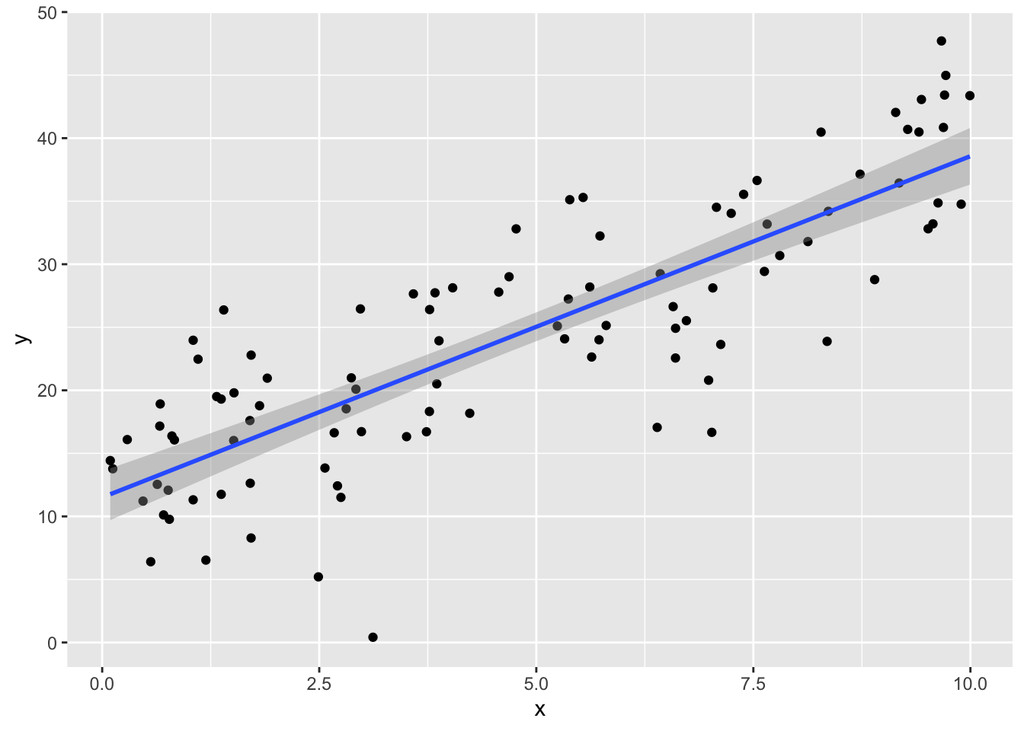

```r
scat <- ggplot(df, aes(x, y)) +
  geom_point() +
  geom_smooth(method = "lm")
  print(scat)
```

- 最初に母数として次の 3 つの値を設定した:

$$切片：α_1=10$$
$$傾き：α_2=3$$
$$標準偏差：sigma=6$$

- このサンプルから推定値を計算する:

```r
reg1 <- lm(y ~ x, data = df)
summary(reg1)
```

```
Call:
lm(formula = y ~ x, data = df)

Residuals:
     Min       1Q   Median       3Q      Max
-19.5307  -3.4985   0.3789   4.2163  11.0789

Coefficients:
            Estimate Std. Error t value Pr(>|t|)
(Intercept)  11.5055     1.0480   10.98   <2e-16 ***
x             2.7065     0.1852   14.62   <2e-16 ***
---
Signif. codes:  0 '***' 0.001 '**' 0.01 '*' 0.05 '.' 0.1 ' ' 1

Residual standard error: 5.737 on 98 degrees of freedom
Multiple R-squared:  0.6856,    Adjusted R-squared:  0.6823
F-statistic: 213.7 on 1 and 98 DF,  p-value: < 2.2e-16
```

$$切片: Intercept = 11.5055 \\
傾き: Coefficients = 2.7065 \\
標準誤差: Standard.error = 5.737$$

- それぞれの母数 (10, 3, 6) に近い値が得られた
- **confint(reg1)** とコマンドを入力すると係数の95パーセント信頼区間が得られる

```r
confint(reg1)
```

```
               2.5 %   97.5 %
(Intercept) 9.425757 13.58534
x           2.339090  3.07399
```

- この 95 パーセント信頼区間は最初に設定した母数 $α_1=10, α_2=3$ を含んでいる

**ここで得られた信頼区間は 100% の確率で母数を含む**

- 以上の過程を、母数とサンプルサイズは変えずに何度も繰り返す
- 同じコードを何度も繰り返し使うのは面倒なので、関数にする

```r
sim_ols1 <- function(alpha, sigma,   # α は傾き、σ は標準偏差
                     n = 100, 　　 　# サンプルサイズ
                     trials = 10000, # 繰り返し回数を指定
                     x.rng = c(0, 10)) { # 説明変数 x の範囲指定


    empty <- rep(NA, trials)
    df <- data.frame(  　# df に結果を保存
        a1 = empty,　　　# データフレームには次の 9 つの変数を含める
        a1.se = empty,
        a1.lower = empty,
        a1.upper = empty,
        a2 = empty,
        a2.se = empty,
        a2.lower = empty,
        a2.upper = empty,
        sigma.hat = empty
        )

    for (i in 1:trials) { ## loop for trials
        ## generate data
        x <- runif(n, x.rng[1], x.rng[2])
        y <- rnorm(n, alpha[1] + alpha[2] * x, sigma)

        ## fit OLS
        fit <- lm(y ~ x)

        ## sum of squared residuals
        sigma.hat <- summary(fit)$sigma

        ## coefficient estimates
        a1 <- coef(fit)[1]
        a2 <- coef(fit)[2]

        ## standard errors of coefficient estimates
        a1.se <- sqrt(summary(fit)$cov.unscaled[1,1]) * sigma.hat
        a2.se <- sqrt(summary(fit)$cov.unscaled[2,2]) * sigma.hat

        ## 95% CI
        a1.ci95 <- confint(fit)[1,]
        a2.ci95 <- confint(fit)[2,]

        ## save the results
        df[i,] <- c(a1, a1.se, a1.ci95,
                    a2, a2.se, a2.ci95,
                    sigma.hat)
    }
    ## return the data frame
    return(df)
}
```

- この関数を利用して、実際にシミュレーションを行う
- 母数とサンプルサイズ（ここでは規定値の `n = 100` を利用）を指定し、データの生成と回帰式の推定を1,000回繰り返してみる

```r
alpha1 <- 10;
alpha2 <- 3;
sigma = 6
sim.1 <- sim_ols1(alpha = c(alpha1, alpha2),
                  sigma = sigma,
                  trials = 1000)
```

- このシミュレーションで得られた結果は次のとおり

```r
summary(sim.1)
```

```
       a1             a1.se           a1.lower         a1.upper
 Min.   : 5.640   Min.   :0.8696   Min.   : 3.282   Min.   : 7.613
 1st Qu.: 9.152   1st Qu.:1.1216   1st Qu.: 6.738   1st Qu.:11.527
 Median : 9.890   Median :1.1940   Median : 7.532   Median :12.314
 Mean   : 9.946   Mean   :1.1996   Mean   : 7.566   Mean   :12.327
 3rd Qu.:10.772   3rd Qu.:1.2726   3rd Qu.: 8.398   3rd Qu.:13.177
 Max.   :15.434   Max.   :1.5432   Max.   :12.900   Max.   :17.968
       a2            a2.se           a2.lower        a2.upper
 Min.   :2.255   Min.   :0.1579   Min.   :1.814   Min.   :2.696
 1st Qu.:2.863   1st Qu.:0.1949   1st Qu.:2.448   1st Qu.:3.268
 Median :3.006   Median :0.2081   Median :2.590   Median :3.417
 Mean   :3.008   Mean   :0.2080   Mean   :2.595   Mean   :3.421
 3rd Qu.:3.146   3rd Qu.:0.2201   3rd Qu.:2.737   3rd Qu.:3.565
 Max.   :3.725   Max.   :0.2739   Max.   :3.405   Max.   :4.082
   sigma.hat
 Min.   :4.619
 1st Qu.:5.645
 Median :5.953
 Mean   :5.962
 3rd Qu.:6.257
 Max.   :7.190
```

| 変数名 | 詳細 |
| --- | --- |
| **a1** | 切片 (Intercept) の推定値 |
| **a1.se** | 切片 (Intercept) の標準誤差 |
| **a1.lower** | 切片の95パーセント信頼区間（下側） |
| **a1.upper** | 切片の95パーセント信頼区間（上側） |
| **a2** | 傾き (Coefficients) の推定値 |
| **a2.se** | 傾き (Coefficients)の標準誤差 |
| **a2.lower** | 傾きの95パーセント信頼区間（下側） |
| **a2.upper** | 傾きの95パーセント信頼区間（上側） |
| **sigma.hat** | 標準偏差 (standard error) の推定値 |

```r
DT::datatable(sim.1)
```

|  | a1 | a1.se | a1.lower | a1.upper | a2 | a2.se | a2.lower | a2.upper | sigma.hat |
| --- | --- | --- | --- | --- | --- | --- | --- | --- | --- |
| 1 | 8.33335692592447 | 1.22785718296122 | 5.89671430755345 | 10.7699995442955 | 3.08977928832934 | 0.220991635117448 | 2.65122858072015 | 3.52832999593853 | 6.00472279687302 |
| 2 | 10.1675070339499 | 1.05085061400136 | 8.08212819091391 | 12.2528858769858 | 2.76654659682424 | 0.176925475112984 | 2.41544374958908 | 3.11764944405941 | 5.1776770622733 |
| 3 | 9.98995361120481 | 1.16890844221625 | 7.67029285032646 | 12.3096143720832 | 2.89439774083118 | 0.207361900353668 | 2.4828947982743 | 3.30590068338807 | 6.34921354314823 |
| 4 | 10.6161312909116 | 1.19028288971289 | 8.25405363461802 | 12.9782089472051 | 2.92063534594155 | 0.198948836545436 | 2.5258278547048 | 3.31544283717829 | 6.16881866641174 |
| 5 | 11.120620611597 | 1.11624235930666 | 8.90547397820921 | 13.3357672449849 | 2.83964726372592 | 0.195473868271866 | 2.45173573393353 | 3.22755879351832 | 5.8686389484035 |
| 6 | 8.79839967574057 | 1.13908553389313 | 6.53792150582822 | 11.0588778456529 | 3.19019641638074 | 0.224910495364912 | 2.74386885815169 | 3.63652397460979 | 6.30838780188418 |
| 7 | 10.6852225914869 | 1.15463308816382 | 8.3938908061272 | 12.9765543768467 | 3.0089680009829 | 0.202861991551059 | 2.60639498099305 | 3.41154102097275 | 6.17703628106653 |
| 8 | 9.13198155335494 | 1.15165444042291 | 6.84656079749549 | 11.4174023092144 | 3.10604034299159 | 0.19051517584009 | 2.72796917694697 | 3.4841115090362 | 5.57155180905727 |
| 9 | 11.1338289082126 | 1.0162284927544 | 9.11715653799728 | 13.1505012784279 | 3.02781562394082 | 0.199150555473978 | 2.63260782805543 | 3.42302341982622 | 5.71576434838095 |
| 10 | 12.0186432218497 | 1.09516767603523 | 9.84531861152808 | 14.1919678321713 | 2.8713440256 | 0.198728935057593 | 2.47697292170908 | 3.26571512949092 | 5.63014400161226 |

[output cut: 990 more lines]

## 1.1 偏回帰係数（傾き）の理解

- 上で得れたシミュレーションの結果 `sim.1` を使って、説明変数 `x` の係数の推定値 $α_2$ （傾き）の分布を確認してみよう
- 私たちは母数の傾き $α_2 = 3$であることを知っているが、`OLS` はこの数値をうまく推定してくれただろうか？

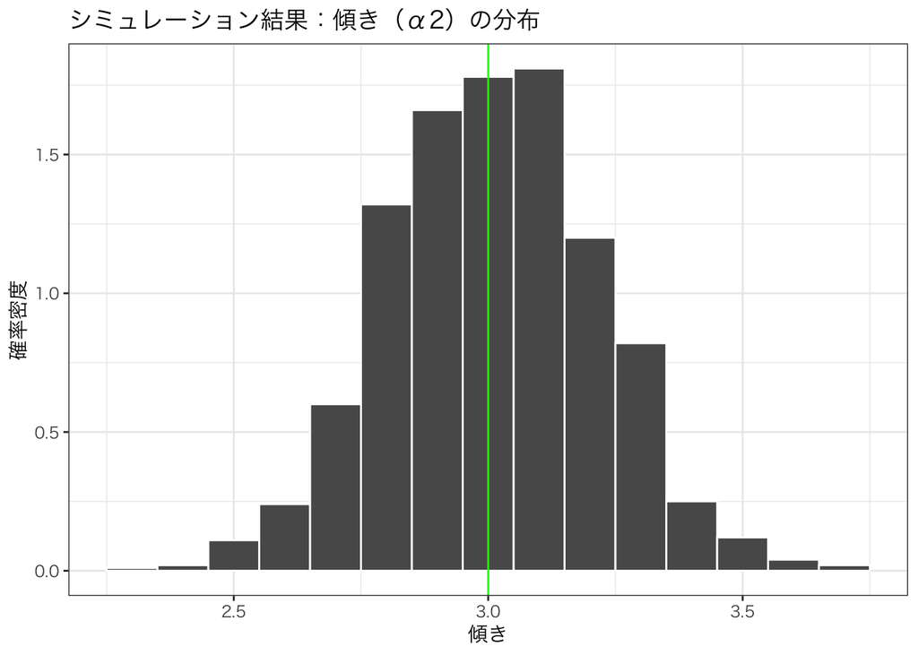

```r
hist.a2 <- ggplot(sim.1,
                  aes(x = a2,
                      y =..density..)) +
  geom_histogram(binwidth = .1, color = "white")

hist.a2 <- hist.a2 + labs(x = "傾き",
                          y = "確率密度",
           title = "シミュレーション結果：傾き（α2）の分布") +
           geom_vline(xintercept = 3, color = "green") + # 傾き= 3 に縦線を引く
  theme_bw(base_family = "HiraKakuProN-W3")

print(hist.a2)
```

- 上記のヒストグラムが示すように、`OLS` は平均すると、母数として設定した $α_2 = 3$ をうまく推定している
- これを**不偏性 (`unbiasedness`）**という
- しかし、常に正しい推定をするわけではない
- 係数の値を過小推定することもあれば、過大推定することもある
- 実際の分析では、データセットが1つしかないのが普通  
  →自分のデータ分析が係数を「正しく」推定しているとは限らならい
- そのために、推定の不確実性を明示することが求められる

## 1.2 標準誤差の理解

- **$α_2$ の標準誤差**をヒストグラムで表示する

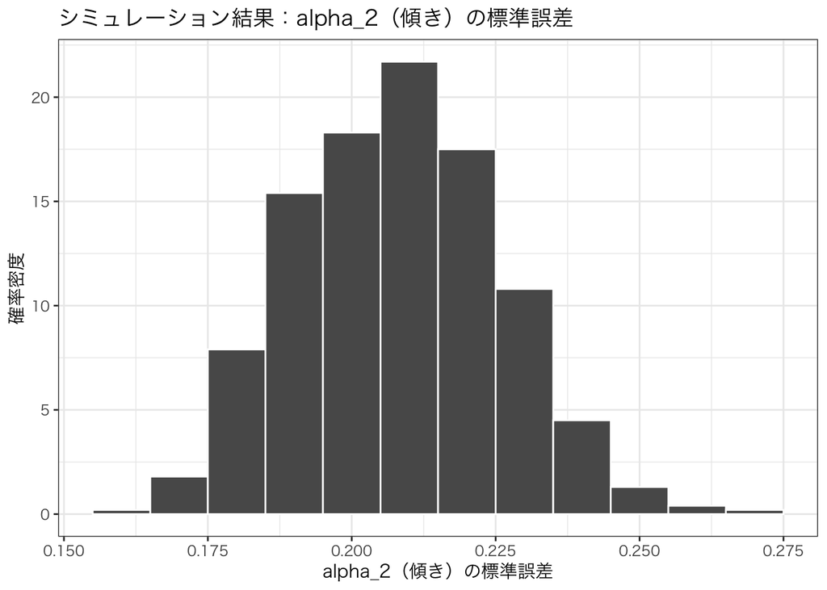

```r
hist.se <- ggplot(sim.1,
                  aes(x = a2.se,      # x 軸に表示するのは α2 の標準誤差
                      y =..density..)) +
    geom_histogram(binwidth = .01,
                   color = "white") +
    labs(x = "alpha_2（傾き）の標準誤差",
         y = "確率密度",
         title = "シミュレーション結果：alpha_2（傾き）の標準誤差")　+
  theme_bw(base_family = "HiraKakuProN-W3")
print(hist.se)
```

$$\frac{\hat{\alpha} -
\alpha}{\mathrm{se}}$$

- これは自由度 $(n-k)$（ここでは、100 - 2 = 98）の $t$ 分布に従うはず
- ここで求めた標準誤差 (`se`) をヒストグラムにして、自由度98の $t$ 分布の確率密度曲線を重ね書きするしてみる

```r
library("dplyr")
```

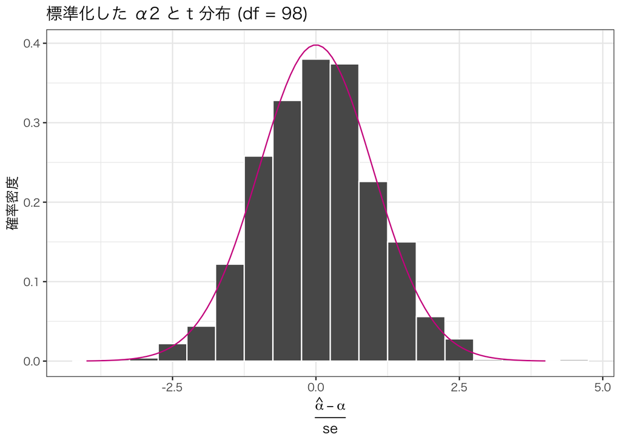

```r
sim.1 <- mutate(sim.1, a2.t = (a2 - alpha2) / a2.se)
　　　　## t分布の確率密度を求め、true.t という名前のデータフレームに保存する
true.t <- data.frame(x = seq(-4, 4, length = 100))
true.t <- mutate(true.t, density = dt(x, df = 98))
hist.t <- ggplot(sim.1, aes(x = a2.t, y =..density..)) +
    geom_histogram(binwidth = 0.5, color = "white") +
    geom_line(data = true.t, aes(x = x, y = density), color = "violetred") +
  theme_bw(base_family = "HiraKakuProN-W3")

hist.t <- hist.t +
    labs(x = expression(frac(hat(alpha) - alpha, "se")),
         y="確率密度", title="標準化した α2 と t 分布 (df = 98)")
print(hist.t)
```

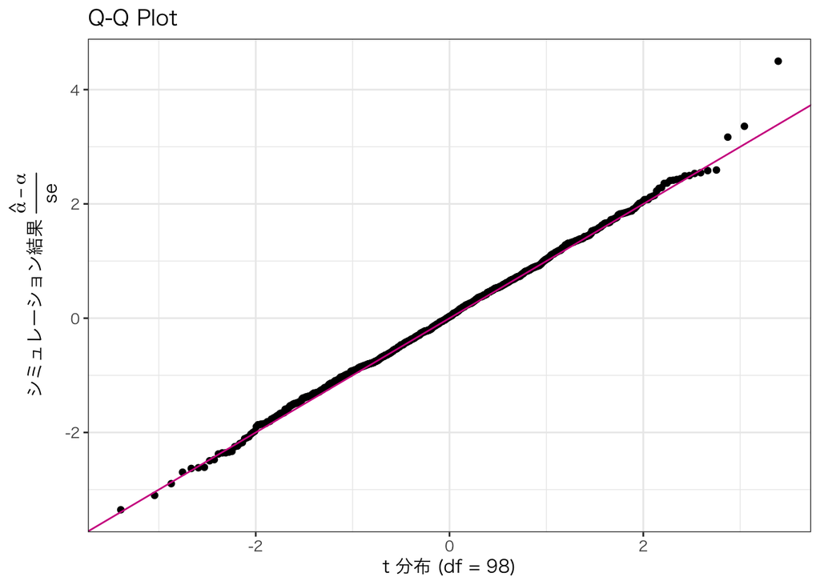

```r
qqplot.t <- ggplot(sim.1, aes(sample = a2.t)) +
    stat_qq(distribution = qt, dparams = list(df = 98)) +
    geom_abline(intercept = 0, slope = 1, color = "violetred") +
    labs(title = "Q-Q Plot",
         x = "t 分布 (df = 98)",
         y = expression(paste("シミュレーション結果 ", frac(hat(alpha) - alpha, "se"), )))　+
  theme_bw(base_family = "HiraKakuProN-W3")
print(qqplot.t)
```

- `Q-Q` プロットの点がほぼ一直線に並んでいる
- $(\hat{\alpha}-\alpha)/\mathrm{se})$が $t$ 分布に従っている
- ただし、分布の裾では、理論値との乖離が大きいことに注意
- 今回のシミュレーションで得られた標準誤差の平均値をもとめてみる

```r
mean(sim.1$a2.se)
```

```
[1] 0.2080031
```

```r
sd(sim.1$a2)
```

```
[1] 0.2077991
```

結果 シミュレーションの結果、**標準誤差 (se)** は推定値の**標準偏差 (sd)**に（ほぼ）一致する